# final project

# Introduction

```r
library(limma)
library(Glimma)
library(edgeR)
library(Homo.sapiens)
library(biomaRt)
```

# Loading the data

To get started with this analysis, download the files from TCGA database on the GDC Data Portal https://portal.gdc.cancer.gov/repository. There will be 30 files loaded into R, and each file representing one patient. The working directory is used to set the location where the files are stored.

```r
    knitr::opts_knit$set(root.dir="~/Documents/TRGN510/final_project/" )
```

```r
files <- c("26dcc91b-b7d5-47c1-8135-e5ab4f4e4be5.htseq.counts", "a8ecb5d8-ece5-43cc-843c-da81dc031ced.htseq.counts", "20cdc1be-7412-4457-ab53-90dcfdf26f93.htseq.counts", "405e401d-d3fc-468c-8c63-c8dddf9b3ee3.htseq.counts", "e1c82878-ac01-45bd-83b0-4bc606039670.htseq.counts", "8d39e856-f93f-4eab-90ef-1e924b059fee.htseq.counts", "89528cea-b21b-4ea8-a271-3d3f3ff142c9.htseq.counts", "29e88863-d1b0-4da0-be95-d0a82eb1d08b.htseq.counts", "b2842754-010e-4f64-905d-89ef3eab3dc9.htseq.counts", "93e77514-c77b-4346-ae63-3e0d10512cff.htseq.counts", "ab461441-1f45-4ae5-b5da-ebb58817f75c.htseq.counts",  "84400ad5-cd37-4a94-a143-5c470599d1ce.htseq.counts",  "2147de22-3a52-490d-a4f6-32f6637ca24f.htseq.counts",  "a8d90f96-19e8-4b2c-a9c8-904a4063d235.htseq.counts", "f00b69a3-c3d2-4499-b337-abbce3e48f9b.htseq.counts", "1d443e1f-794b-45bb-ae6f-91f57d5fca33.htseq.counts", "3dce2e68-bcf1-42b6-9374-b2724a0f5242.htseq.counts", "5c9f1a05-1dc7-4e83-8dc2-3e5071796c07.htseq.counts", "7a790ece-2c1a-4895-a475-9fabbc0622a3.htseq.counts", "34e77fac-9e4b-481c-9a6c-a1b5f0916f06.htseq.counts", "426b94fe-fcff-49f2-9d0b-c7cb49bb5559.htseq.counts", "984ea13e-adc6-48f7-830d-66ce450a2ea0.htseq.counts", "2950c137-45e0-458f-987f-31de7f7befc4.htseq.counts",
"60547e35-d42f-44bd-a9e8-21d57da93ee8.htseq.counts",
"a7d05ea6-aa28-457f-a20b-57e812b614e1.htseq.counts",
"bed7e30b-bf94-41d1-80f6-0595ff21bd3e.htseq.counts",
"d7e7ad52-ecde-4744-b4e7-28dea4d186da.htseq.counts",
"df0b7118-2a68-420e-a1dd-236e05bc8fe8.htseq.counts",
"f426d6b8-5010-471c-aa9c-253269f6bc03.htseq.counts",
"f3876e31-2267-458d-826f-769bcfb34e56.htseq.counts")
```

The files are stored in a collective location. The first five rows are read as an example and printed as a result. The data has 2 columns, the column on the left side is ENSEMBL GENE ID and the column on the right is the number of counts . THE ENSEMBL GENE ID is in the format: ENS(species)(object type)(identifier). (version) The files do not contain a header, so the column heads are denoted as V1 and V2.

```r
read.delim(files[1], nrow=5, header=FALSE)
```

```
##                   V1   V2
## 1 ENSG00000000003.13 4831
## 2  ENSG00000000005.5   19
## 3 ENSG00000000419.11 1415
## 4 ENSG00000000457.12 1095
## 5 ENSG00000000460.15  187
```

```r
getwd()
```

```
## [1] "/Users/evazhu/Documents/TRGN510/final_project"
```

## Group the data

The content of each file is combined into one dataframe by using “readDGE” function, and the location of new combined data is called “x”. The data is sorted based on the parameter of white vs. African American. EdgeR provides a easy method to perform this with a single command “readDGE”.

```r
x <- readDGE(files, columns=c(1,2))
```

```
## Meta tags detected: __no_feature, __ambiguous, __too_low_aQual, __not_aligned, __alignment_not_unique
```

```r
class(x)
```

```
## [1] "DGEList"
## attr(,"package")
## [1] "edgeR"
```

The dimensions of the dataframe are printed. Each file contains 60487 genes (rows) and have a sample size of 30 people (15 white female and 15 African American female) or 30 columns.

```r
dim(x)
```

```
## [1] 60487    30
```

The code below could help to label all the columns in data frame “x” according to related files.

```r
samplenames<-colnames(x)
sampleNames
```

[output not shown]

```r
colnames(x) <- samplenames
```

## Organizing the data

The samples are grouped based on their race. And the information needs to be associated with the columns of the counts matrix. For the tumor grade, Stage 1 and 2 would be define as “low grade”, and stage 3 and 4 would be define as “high grade”.

```r
group <- c(rep("AfricanAmerican",15), rep("White",15))
x$samples$group <- group
tumorgrade <-c("low", "low", "low", "low", "high", "low", "low", "low", "low", "low", "high", "low", "low", "low", "low", "low", "low", "high", "low", "low", "low", "high", "high", "low", "high", "high", "low", "high", "low", "low")
x$samples$tumorgrade <- tumorgrade
x$samples
```

```
##                                                                                        files
## 26dcc91b-b7d5-47c1-8135-e5ab4f4e4be5.htseq 26dcc91b-b7d5-47c1-8135-e5ab4f4e4be5.htseq.counts
## a8ecb5d8-ece5-43cc-843c-da81dc031ced.htseq a8ecb5d8-ece5-43cc-843c-da81dc031ced.htseq.counts
## 20cdc1be-7412-4457-ab53-90dcfdf26f93.htseq 20cdc1be-7412-4457-ab53-90dcfdf26f93.htseq.counts
## 405e401d-d3fc-468c-8c63-c8dddf9b3ee3.htseq 405e401d-d3fc-468c-8c63-c8dddf9b3ee3.htseq.counts
## e1c82878-ac01-45bd-83b0-4bc606039670.htseq e1c82878-ac01-45bd-83b0-4bc606039670.htseq.counts
## 8d39e856-f93f-4eab-90ef-1e924b059fee.htseq 8d39e856-f93f-4eab-90ef-1e924b059fee.htseq.counts
## 89528cea-b21b-4ea8-a271-3d3f3ff142c9.htseq 89528cea-b21b-4ea8-a271-3d3f3ff142c9.htseq.counts
## 29e88863-d1b0-4da0-be95-d0a82eb1d08b.htseq 29e88863-d1b0-4da0-be95-d0a82eb1d08b.htseq.counts
## b2842754-010e-4f64-905d-89ef3eab3dc9.htseq b2842754-010e-4f64-905d-89ef3eab3dc9.htseq.counts
## 93e77514-c77b-4346-ae63-3e0d10512cff.htseq 93e77514-c77b-4346-ae63-3e0d10512cff.htseq.counts
## ab461441-1f45-4ae5-b5da-ebb58817f75c.htseq ab461441-1f45-4ae5-b5da-ebb58817f75c.htseq.counts
## 84400ad5-cd37-4a94-a143-5c470599d1ce.htseq 84400ad5-cd37-4a94-a143-5c470599d1ce.htseq.counts
## 2147de22-3a52-490d-a4f6-32f6637ca24f.htseq 2147de22-3a52-490d-a4f6-32f6637ca24f.htseq.counts
## a8d90f96-19e8-4b2c-a9c8-904a4063d235.htseq a8d90f96-19e8-4b2c-a9c8-904a4063d235.htseq.counts
## f00b69a3-c3d2-4499-b337-abbce3e48f9b.htseq f00b69a3-c3d2-4499-b337-abbce3e48f9b.htseq.counts
## 1d443e1f-794b-45bb-ae6f-91f57d5fca33.htseq 1d443e1f-794b-45bb-ae6f-91f57d5fca33.htseq.counts
## 3dce2e68-bcf1-42b6-9374-b2724a0f5242.htseq 3dce2e68-bcf1-42b6-9374-b2724a0f5242.htseq.counts
## 5c9f1a05-1dc7-4e83-8dc2-3e5071796c07.htseq 5c9f1a05-1dc7-4e83-8dc2-3e5071796c07.htseq.counts
## 7a790ece-2c1a-4895-a475-9fabbc0622a3.htseq 7a790ece-2c1a-4895-a475-9fabbc0622a3.htseq.counts
## 34e77fac-9e4b-481c-9a6c-a1b5f0916f06.htseq 34e77fac-9e4b-481c-9a6c-a1b5f0916f06.htseq.counts
## 426b94fe-fcff-49f2-9d0b-c7cb49bb5559.htseq 426b94fe-fcff-49f2-9d0b-c7cb49bb5559.htseq.counts
## 984ea13e-adc6-48f7-830d-66ce450a2ea0.htseq 984ea13e-adc6-48f7-830d-66ce450a2ea0.htseq.counts
## 2950c137-45e0-458f-987f-31de7f7befc4.htseq 2950c137-45e0-458f-987f-31de7f7befc4.htseq.counts
## 60547e35-d42f-44bd-a9e8-21d57da93ee8.htseq 60547e35-d42f-44bd-a9e8-21d57da93ee8.htseq.counts
## a7d05ea6-aa28-457f-a20b-57e812b614e1.htseq a7d05ea6-aa28-457f-a20b-57e812b614e1.htseq.counts
## bed7e30b-bf94-41d1-80f6-0595ff21bd3e.htseq bed7e30b-bf94-41d1-80f6-0595ff21bd3e.htseq.counts
## d7e7ad52-ecde-4744-b4e7-28dea4d186da.htseq d7e7ad52-ecde-4744-b4e7-28dea4d186da.htseq.counts
## df0b7118-2a68-420e-a1dd-236e05bc8fe8.htseq df0b7118-2a68-420e-a1dd-236e05bc8fe8.htseq.counts
## f426d6b8-5010-471c-aa9c-253269f6bc03.htseq f426d6b8-5010-471c-aa9c-253269f6bc03.htseq.counts
## f3876e31-2267-458d-826f-769bcfb34e56.htseq f3876e31-2267-458d-826f-769bcfb34e56.htseq.counts
##                                                      group  lib.size
## 26dcc91b-b7d5-47c1-8135-e5ab4f4e4be5.htseq AfricanAmerican  88057075
## a8ecb5d8-ece5-43cc-843c-da81dc031ced.htseq AfricanAmerican  36762372
## 20cdc1be-7412-4457-ab53-90dcfdf26f93.htseq AfricanAmerican  94832977
## 405e401d-d3fc-468c-8c63-c8dddf9b3ee3.htseq AfricanAmerican  70538691
## e1c82878-ac01-45bd-83b0-4bc606039670.htseq AfricanAmerican  79334204
## 8d39e856-f93f-4eab-90ef-1e924b059fee.htseq AfricanAmerican  92174541
## 89528cea-b21b-4ea8-a271-3d3f3ff142c9.htseq AfricanAmerican  71614606
## 29e88863-d1b0-4da0-be95-d0a82eb1d08b.htseq AfricanAmerican  56132077
```

[output cut: 38 more lines]

```
## 1d443e1f-794b-45bb-ae6f-91f57d5fca33.htseq            1        low
## 3dce2e68-bcf1-42b6-9374-b2724a0f5242.htseq            1        low
## 5c9f1a05-1dc7-4e83-8dc2-3e5071796c07.htseq            1       high
## 7a790ece-2c1a-4895-a475-9fabbc0622a3.htseq            1        low
## 34e77fac-9e4b-481c-9a6c-a1b5f0916f06.htseq            1        low
## 426b94fe-fcff-49f2-9d0b-c7cb49bb5559.htseq            1        low
## 984ea13e-adc6-48f7-830d-66ce450a2ea0.htseq            1       high
## 2950c137-45e0-458f-987f-31de7f7befc4.htseq            1       high
## 60547e35-d42f-44bd-a9e8-21d57da93ee8.htseq            1        low
## a7d05ea6-aa28-457f-a20b-57e812b614e1.htseq            1       high
## bed7e30b-bf94-41d1-80f6-0595ff21bd3e.htseq            1       high
## d7e7ad52-ecde-4744-b4e7-28dea4d186da.htseq            1        low
## df0b7118-2a68-420e-a1dd-236e05bc8fe8.htseq            1       high
## f426d6b8-5010-471c-aa9c-253269f6bc03.htseq            1        low
## f3876e31-2267-458d-826f-769bcfb34e56.htseq            1        low
```

Since the “homo.sapiens” package doesn’t include the ENSEMBL Gene ID in the format provided by the loaded data, the data should convert using a substitution function. The digits following the decimal are replaced to match the key.

```r
library(gsubfn)
library(biomaRt)
```

```r
geneid <- rownames(x)
geneid <- gsub("\\.[0-9]*$", "", geneid)
head(geneid)
```

```
## [1] "ENSG00000000005" "ENSG00000000419" "ENSG00000000457" "ENSG00000000460"
## [5] "ENSG00000000938" "ENSG00000000971"
```

The dataframe genes is used to store gene-level information related to rows of genes. The info we need for this data frame is retrieved from the ‘Homo.sapiens’. The GeneIDs are related to the symbol and the chromosome number of each gene. The columns of SYMBOL, TXCHROM, and ENSEMBL gene ID are mixed and couldn’t separate in the three columns. But when I did the next step and removed the duplicated genes from our dataset, the SYMBOL, TXCHROM, and ENSEMBL can be separated and shown normally. And all the data and functions are presented and worked successfully in the following steps. I already note this in the Known Issue of README file.

```r
genes <- select(Homo.sapiens, keys=geneid, columns=c("SYMBOL", "TXCHROM"),
                keytype="ENSEMBL")
heads(genes)
```

```
##    group group_name           value
## 1      1    ENSEMBL ENSG00000000005
## 2      1    ENSEMBL ENSG00000000419
## 3      1    ENSEMBL ENSG00000000457
## 4      1    ENSEMBL ENSG00000000460
## 5      1    ENSEMBL ENSG00000000938
## 6      1    ENSEMBL ENSG00000000971
## 7      2     SYMBOL            TNMD
## 8      2     SYMBOL            DPM1
## 9      2     SYMBOL           SCYL3
## 10     2     SYMBOL        C1orf112
## 11     2     SYMBOL             FGR
## 12     2     SYMBOL             CFH
## 13     3    TXCHROM            chrX
## 14     3    TXCHROM           chr20
## 15     3    TXCHROM            chr1
## 16     3    TXCHROM            chr1
## 17     3    TXCHROM            chr1
## 18     3    TXCHROM            chr1
```

The duplicated genes would be removed from our dataset

```r
genes <- genes[!duplicated(genes$ENSEMBL),]
x$genes <- genes
x
```

```
## An object of class "DGEList"
## $samples
##                                                                                        files
## 26dcc91b-b7d5-47c1-8135-e5ab4f4e4be5.htseq 26dcc91b-b7d5-47c1-8135-e5ab4f4e4be5.htseq.counts
## a8ecb5d8-ece5-43cc-843c-da81dc031ced.htseq a8ecb5d8-ece5-43cc-843c-da81dc031ced.htseq.counts
## 20cdc1be-7412-4457-ab53-90dcfdf26f93.htseq 20cdc1be-7412-4457-ab53-90dcfdf26f93.htseq.counts
## 405e401d-d3fc-468c-8c63-c8dddf9b3ee3.htseq 405e401d-d3fc-468c-8c63-c8dddf9b3ee3.htseq.counts
## e1c82878-ac01-45bd-83b0-4bc606039670.htseq e1c82878-ac01-45bd-83b0-4bc606039670.htseq.counts
##                                                      group lib.size
## 26dcc91b-b7d5-47c1-8135-e5ab4f4e4be5.htseq AfricanAmerican 88057075
## a8ecb5d8-ece5-43cc-843c-da81dc031ced.htseq AfricanAmerican 36762372
## 20cdc1be-7412-4457-ab53-90dcfdf26f93.htseq AfricanAmerican 94832977
## 405e401d-d3fc-468c-8c63-c8dddf9b3ee3.htseq AfricanAmerican 70538691
## e1c82878-ac01-45bd-83b0-4bc606039670.htseq AfricanAmerican 79334204
##                                            norm.factors tumorgrade
## 26dcc91b-b7d5-47c1-8135-e5ab4f4e4be5.htseq            1        low
## a8ecb5d8-ece5-43cc-843c-da81dc031ced.htseq            1        low
## 20cdc1be-7412-4457-ab53-90dcfdf26f93.htseq            1        low
## 405e401d-d3fc-468c-8c63-c8dddf9b3ee3.htseq            1        low
## e1c82878-ac01-45bd-83b0-4bc606039670.htseq            1       high
## 25 more rows ...
##
## $counts
##                     Samples
## Tags                 26dcc91b-b7d5-47c1-8135-e5ab4f4e4be5.htseq
##   ENSG00000000005.5                                          19
##   ENSG00000000419.11                                       1415
##   ENSG00000000457.12                                       1095
##   ENSG00000000460.15                                        187
##   ENSG00000000938.11                                        381
##                     Samples
## Tags                 a8ecb5d8-ece5-43cc-843c-da81dc031ced.htseq
##   ENSG00000000005.5                                           1
##   ENSG00000000419.11                                        670
##   ENSG00000000457.12                                        440
##   ENSG00000000460.15                                        167
##   ENSG00000000938.11                                        628
##                     Samples
## Tags                 20cdc1be-7412-4457-ab53-90dcfdf26f93.htseq
##   ENSG00000000005.5                                           1
```

[output cut: 188 more lines]

```
##   ENSG00000000005.5                                          26
##   ENSG00000000419.11                                        991
##   ENSG00000000457.12                                        741
##   ENSG00000000460.15                                        212
##   ENSG00000000938.11                                        577
## 60482 more rows ...
##
## $genes
##           ENSEMBL   SYMBOL TXCHROM
## 1 ENSG00000000005     TNMD    chrX
## 2 ENSG00000000419     DPM1   chr20
## 3 ENSG00000000457    SCYL3    chr1
## 4 ENSG00000000460 C1orf112    chr1
## 5 ENSG00000000938      FGR    chr1
## 60482 more rows ...
```

# Data Pre-processing

## Transformation from the raw-scale

My data will be transformed from raw data to the useable form. And we would do the calculation of counts per million(cpm) and log of counts per million (lcpm)

```r
cpm <- cpm(x)
lcpm <- cpm(x, log=TRUE)
```

More calculation is shown below. L is the average library size in millions. M is the median of the library size in millions.

```r
L <- mean(x$samples$lib.size) * 1e-6
M <- median(x$samples$lib.size) * 1e-6
c(L, M)
```

```
## [1] 86.87360 89.56681
```

The summary of the lcpm calculation is presented

```r
summary(lcpm)
```

```
##  26dcc91b-b7d5-47c1-8135-e5ab4f4e4be5.htseq
##  Min.   :-5.4408
##  1st Qu.:-5.4408
##  Median :-4.8624
##  Mean   :-2.4792
##  3rd Qu.:-0.1023
##  Max.   :17.5725
##  a8ecb5d8-ece5-43cc-843c-da81dc031ced.htseq
##  Min.   :-5.4408
##  1st Qu.:-5.4408
##  Median :-4.3155
##  Mean   :-2.3861
##  3rd Qu.: 0.2542
##  Max.   :17.6378
##  20cdc1be-7412-4457-ab53-90dcfdf26f93.htseq
##  Min.   :-5.4408
##  1st Qu.:-5.4408
##  Median :-4.8968
##  Mean   :-2.5489
##  3rd Qu.:-0.3937
##  Max.   :17.4003
##  405e401d-d3fc-468c-8c63-c8dddf9b3ee3.htseq
##  Min.   :-5.4408
##  1st Qu.:-5.4408
##  Median :-5.4408
##  Mean   :-2.8541
##  3rd Qu.:-0.9456
##  Max.   :18.2016
##  e1c82878-ac01-45bd-83b0-4bc606039670.htseq
##  Min.   :-5.4408
##  1st Qu.:-5.4408
##  Median :-4.8109
##  Mean   :-2.7033
##  3rd Qu.:-0.7003
##  Max.   :17.8197
##  8d39e856-f93f-4eab-90ef-1e924b059fee.htseq
##  Min.   :-5.4408
##  1st Qu.:-5.4408
##  Median :-4.8838
##  Mean   :-2.5702
```

[output cut: 155 more lines]

```
##  Max.   :17.6246
##  f426d6b8-5010-471c-aa9c-253269f6bc03.htseq
##  Min.   :-5.4408
##  1st Qu.:-5.4408
##  Median :-4.9342
##  Mean   :-2.5372
##  3rd Qu.:-0.2408
##  Max.   :17.6763
##  f3876e31-2267-458d-826f-769bcfb34e56.htseq
##  Min.   :-5.44085
##  1st Qu.:-5.44085
##  Median :-4.10012
##  Mean   :-2.30152
##  3rd Qu.: 0.01589
##  Max.   :17.68753
```

## Removing the genes that are lowly expressed

The expressions of some genes are low and it’s not helpful to do the statistical analysis in a meaningful way. And we found the low expression-genes are in both data groups. So to understand the ratio of these genes, we could run the following lines.

```r
table(rowSums(x$counts==0)==9)
```

```
##
## FALSE  TRUE
## 59807   680
```

EdgeR package gave an easy way to get rid of these lowly expressed genes.

```r
keep.exprs <- filterByExpr(x, group=group)
x <- x[keep.exprs,, keep.lib.sizes=FALSE]
dim(x)
```

```
## [1] 20998    30
```

It showed the number of genes for interpretation reduced from 60487 to 20998. The raw data versus filtered data is shown in a graphical manner using the following lines of code. The package “RColorBrewer” contribute to create visually appealing graphs.

```r
lcpm.cutoff <- log2(10/M + 2/L)
library(RColorBrewer)
nsamples <- ncol(x)
col <- brewer.pal(nsamples, "Paired")
```

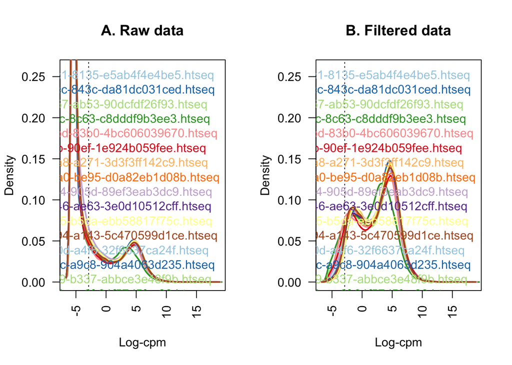

```r
par(mfrow=c(1,2))
plot(density(lcpm[,1]), col=col[1], lwd=2, ylim=c(0,0.26), las=2, main="", xlab="")
title(main="A. Raw data", xlab="Log-cpm")
abline(v=lcpm.cutoff, lty=3)
for (i in 2:nsamples){
den <- density(lcpm[,i])
lines(den$x, den$y, col=col[i], lwd=2)
}
legend("topright", samplenames, text.col=col, bty="n")
lcpm <- cpm(x, log=TRUE)
plot(density(lcpm[,1]), col=col[1], lwd=2, ylim=c(0,0.26), las=2, main="", xlab="")
title(main="B. Filtered data", xlab="Log-cpm")
abline(v=lcpm.cutoff, lty=3)
for (i in 2:nsamples){
den <- density(lcpm[,i])
lines(den$x, den$y, col=col[i], lwd=2)
}
legend("topright", samplenames, text.col=col, bty="n")
```

## Normalizing gene expression distribution

For normalization of the data, edgeR provides a great function to help us analyze the data. The resultant values are stored in a dataset called norm.factors.

```r
x<- calcNormFactors(x, method = "TMM")
x$samples$norm.factors
```

```
##  [1] 1.0677045 1.1755082 1.1321045 0.6065625 0.8859745 1.0645391 1.1663100
##  [8] 1.1178039 1.0567642 1.1178308 1.1535242 1.1177813 1.1227591 0.8747468
## [15] 0.6091573 1.0964542 0.9830666 1.0758909 1.0717371 1.0436450 0.9512229
## [22] 0.9956307 0.8770367 0.7929302 0.8548798 0.9352151 1.1810664 1.0415226
## [29] 1.0615824 1.1610027
```

```r
x2 <- x
x2$samples$norm.factors <- 1
x2$counts[,1] <- ceiling(x2$counts[,1]*0.05)
x2$counts[,2] <- x2$counts[,2]*5
```

The graph below plots the data that is normalized versus non-normalized.

```
##  [1] 0.06222719 6.08807245 1.17538687 0.63397782 0.90699063 1.11865961
##  [7] 1.20226851 1.16069655 1.11009858 1.17518939 1.22352128 1.16017474
## [13] 1.18453776 0.91737107 0.63526050 1.12046522 1.02595107 1.08180579
## [19] 1.11238423 1.08035508 1.02280563 1.04049720 0.90319154 0.82602320
## [25] 0.90963126 0.99343570 1.23595545 1.09549760 1.10706548 1.21764186
```

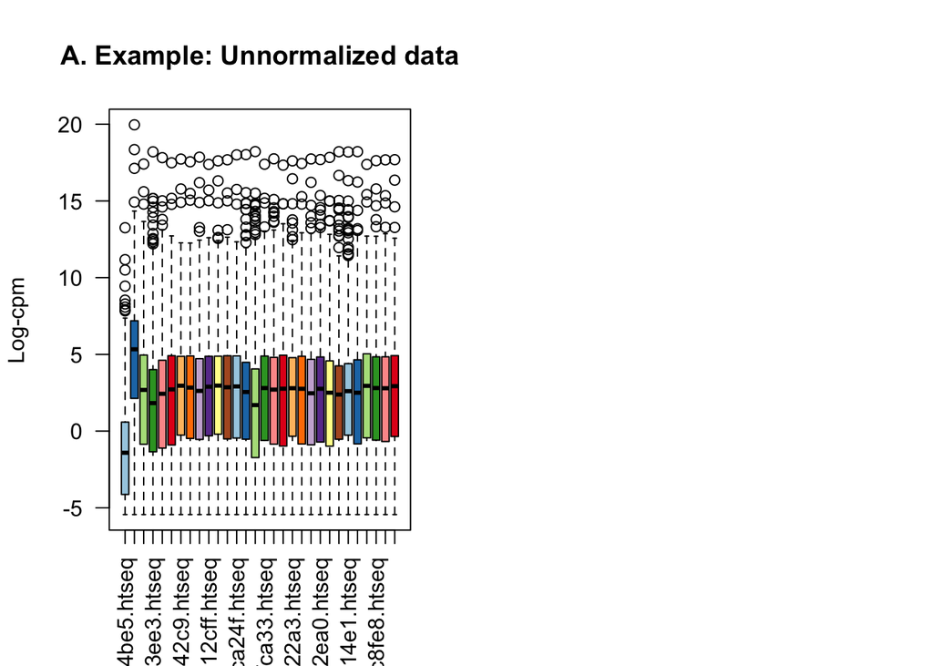

```r
par(mfrow=c(1,2))
lcpm <- cpm(x2, log=TRUE)
boxplot(lcpm, las=2, col=col, main="")
title(main="A. Example: Unnormalized data",ylab="Log-cpm")
x2 <- calcNormFactors(x2)
x2$samples$norm.factors
```

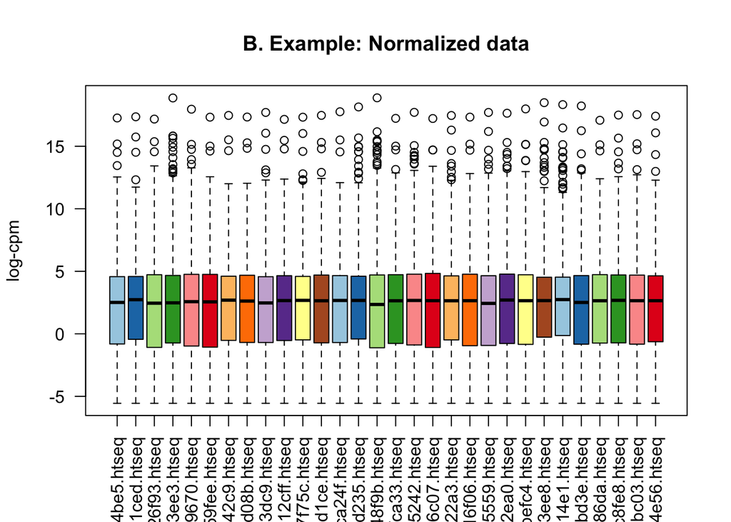

```r
lcpm <- cpm(x2, log=TRUE)
boxplot(lcpm, las=2, col=col, main="")
title(main ="B. Example: Normalized data",ylab = "log-cpm")
```

## Unsupervised clustering of samples

The MDS plot is a method to visualize the level of similarity and the dissimilarities of individual cases of a dataset. The extent of the differences can give an idea of the expected consequence of the differential expression analysis. The plotMDS function of limma can help us to generate the plot. The distances on the plot would show the action of different categories on this data.

```r
library(limma)
library(Glimma)
lcpm <- cpm(x, log=TRUE)
par(mfrow=c(1,2))
col.group <- group
levels(col.group) <- brewer.pal(nlevels(col.group), "Set1")
col.group <- as.character(col.group)
col.tumorgrade <- tumorgrade
levels(col.tumorgrade) <- brewer.pal(nlevels(col.tumorgrade), "Set2")
```

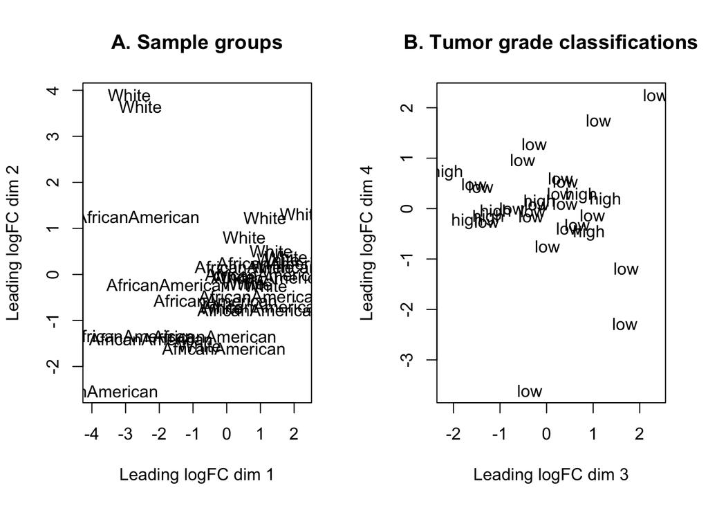

```r
col.tumorgrade <- as.character(col.tumorgrade)
col.group <- c("purple","orange")[group]
col.tumorgrade <- c("red","blue")[tumorgrade]
plotMDS(lcpm, labels=group, col=col.group)
title(main="A. Sample groups")
plotMDS(lcpm, labels=tumorgrade, col=col.tumorgrade, dim=c(3,4))
title(main="B. Tumor grade classifications")
```

The interactive version of this graph can be launched using glimma.

```r
glMDSPlot(lcpm,labels=paste(group, tumorgrade, sep="_"),
          groups=x$samples[,c(2,5)], launch=TRUE)
```

# Differential Expression Analysis

## Creating a design matrix and contrasts

The first step of doing the differential expression analysis is to create a design matrix with both the African American group of data and white group of data. Another column within the matrix, which the co-variate “tumor grade” will also be generated.

```r
design <- model.matrix(~0+group+tumorgrade)
colnames(design) <- gsub("group", "", colnames(design))
design
```

```
##    AfricanAmerican White tumorgradelow
## 1                1     0             1
## 2                1     0             1
## 3                1     0             1
## 4                1     0             1
## 5                1     0             0
## 6                1     0             1
## 7                1     0             1
## 8                1     0             1
## 9                1     0             1
## 10               1     0             1
## 11               1     0             0
## 12               1     0             1
## 13               1     0             1
## 14               1     0             1
```

[output cut: 24 more lines]

Comparing the two groups are created and stored in a matrix

```r
contr.matrix <- makeContrasts(
  AfricanAmericanVSWhite = AfricanAmerican-White,
  levels = colnames(design))
contr.matrix
```

```
##                  Contrasts
## Levels            AfricanAmericanVSWhite
##   AfricanAmerican                      1
##   White                               -1
##   tumorgradelow                        0
```

## Removing heteroscedascity from count data

Voom is a function within limma that would transfer the raw data into normalized data that can help us know the mean-variance relationship.

```
## An object of class "EList"
## $genes
##           ENSEMBL   SYMBOL TXCHROM
## 1 ENSG00000000005     TNMD    chrX
## 2 ENSG00000000419     DPM1   chr20
## 3 ENSG00000000457    SCYL3    chr1
## 4 ENSG00000000460 C1orf112    chr1
## 5 ENSG00000000938      FGR    chr1
## 20993 more rows ...
##
## $targets
##                                                                                        files
## 26dcc91b-b7d5-47c1-8135-e5ab4f4e4be5.htseq 26dcc91b-b7d5-47c1-8135-e5ab4f4e4be5.htseq.counts
## a8ecb5d8-ece5-43cc-843c-da81dc031ced.htseq a8ecb5d8-ece5-43cc-843c-da81dc031ced.htseq.counts
## 20cdc1be-7412-4457-ab53-90dcfdf26f93.htseq 20cdc1be-7412-4457-ab53-90dcfdf26f93.htseq.counts
## 405e401d-d3fc-468c-8c63-c8dddf9b3ee3.htseq 405e401d-d3fc-468c-8c63-c8dddf9b3ee3.htseq.counts
## e1c82878-ac01-45bd-83b0-4bc606039670.htseq e1c82878-ac01-45bd-83b0-4bc606039670.htseq.counts
##                                                      group  lib.size
## 26dcc91b-b7d5-47c1-8135-e5ab4f4e4be5.htseq AfricanAmerican  93815317
## a8ecb5d8-ece5-43cc-843c-da81dc031ced.htseq AfricanAmerican  43170011
## 20cdc1be-7412-4457-ab53-90dcfdf26f93.htseq AfricanAmerican 107052885
## 405e401d-d3fc-468c-8c63-c8dddf9b3ee3.htseq AfricanAmerican  42761150
## e1c82878-ac01-45bd-83b0-4bc606039670.htseq AfricanAmerican  70256069
##                                            norm.factors tumorgrade
## 26dcc91b-b7d5-47c1-8135-e5ab4f4e4be5.htseq    1.0677045        low
## a8ecb5d8-ece5-43cc-843c-da81dc031ced.htseq    1.1755082        low
## 20cdc1be-7412-4457-ab53-90dcfdf26f93.htseq    1.1321045        low
## 405e401d-d3fc-468c-8c63-c8dddf9b3ee3.htseq    0.6065625        low
## e1c82878-ac01-45bd-83b0-4bc606039670.htseq    0.8859745       high
## 25 more rows ...
##
## $E
##                     Samples
## Tags                 26dcc91b-b7d5-47c1-8135-e5ab4f4e4be5.htseq
##   ENSG00000000005.5                                  -2.2663494
##   ENSG00000000419.11                                  3.9153444
##   ENSG00000000457.12                                  3.5456222
##   ENSG00000000460.15                                  0.9989952
##   ENSG00000000938.11                                  2.0237876
##                     Samples
```

[output cut: 230 more lines]

```
## [1,] 0.6125211 0.5640269
## [2,] 2.7147504 2.2396752
## [3,] 2.2169995 1.7098574
## [4,] 1.1493590 0.9550277
## [5,] 2.2997592 1.7833773
## 20993 more rows ...
##
## $design
##   AfricanAmerican White tumorgradelow
## 1               1     0             1
## 2               1     0             1
## 3               1     0             1
## 4               1     0             1
## 5               1     0             0
## 25 more rows ...
```

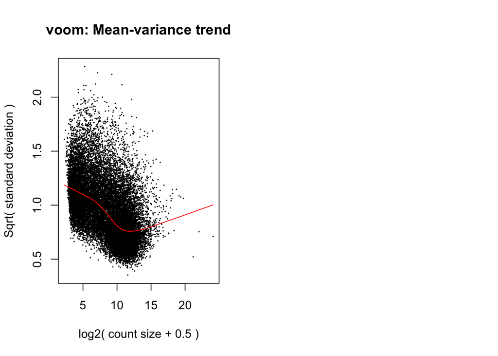

```r
par(mfrow=c(1,2))
v <- voom(x, design, plot = TRUE)
v
```

In the following two plots, it showed the relationship between the mean and variances of the data. By using voom, we can see the first the relationship in first graph before the data is normalized. The effect of normalization can be visualized through the lines of the best fit. To view the differential expression levels, we can generate the following table. (Up-up-regulated genes)

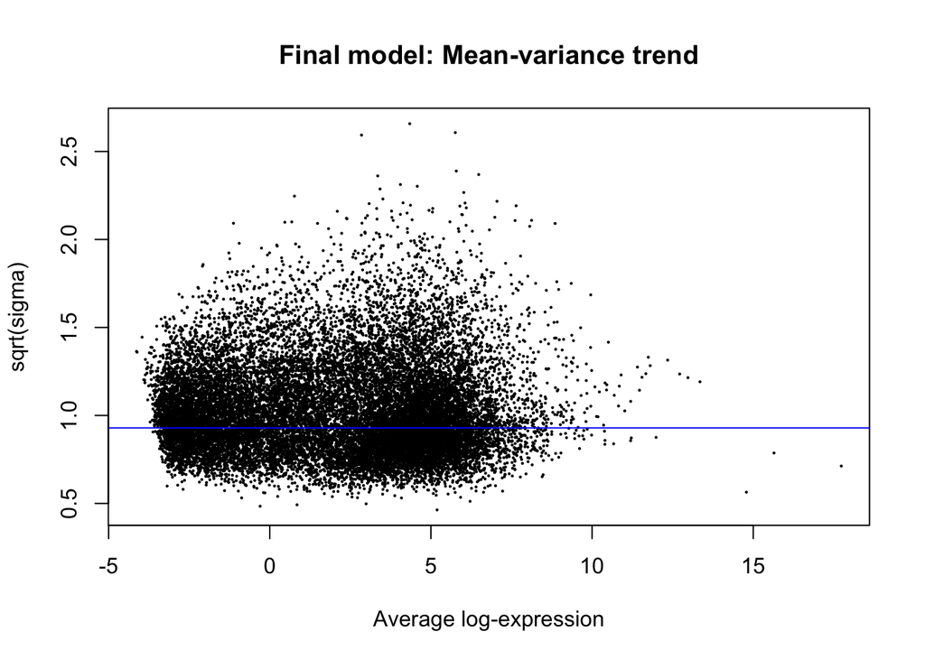

```r
vfit <- lmFit(v, design)
vfit <- contrasts.fit(vfit,contrasts = contr.matrix)
efit <- eBayes(vfit)
plotSA(efit, main="Final model: Mean-variance trend")
```

## Examining the number of differentially expressed genes

T-statistics would show a more stringent definition of significance to be applied to the data. In the table below, it showed there are 3 genes are down-regulated and 4 genes are up-regulated.

```r
summary(decideTests(efit))
```

```
##        AfricanAmericanVSWhite
## Down                        3
## NotSig                  20991
## Up                          4
```

We could use the treat method to do the additional filtering of significant genes. The filter requires genes to have a log-fold change bigger than a predetermined value. In the beginning, I didn’t see a lot of significant genes through the default cut-offs. In this situation, we could lower the thresholds to identify the most significant genes with the largest effect size. And I set the lfc to 0.1. Now, there are 4 genes significantly up-regulated and 2 genes significantly down-regulated.

```r
tfit <- treat(vfit, lfc=0.1)
dt <- decideTests(tfit)
summary(dt)
```

```
##        AfricanAmericanVSWhite
## Down                        2
## NotSig                  20992
## Up                          4
```

After the changes of “lfc”, I got 6 significant gene expression.

```r
de.common <- which(dt[,1]!=0)
length(de.common)
```

```
## [1] 6
```

Now, we can see the names of the genes from the de.common list using the following code:

```r
head(tfit$genes$SYMBOL[de.common], n=30)
```

```
## [1] "GSTM1"     "OTOGL"     NA          "LINC01788" NA          NA
```

The vennDiagram function can be used to visualize the DE genes that associated with two groups of patients.

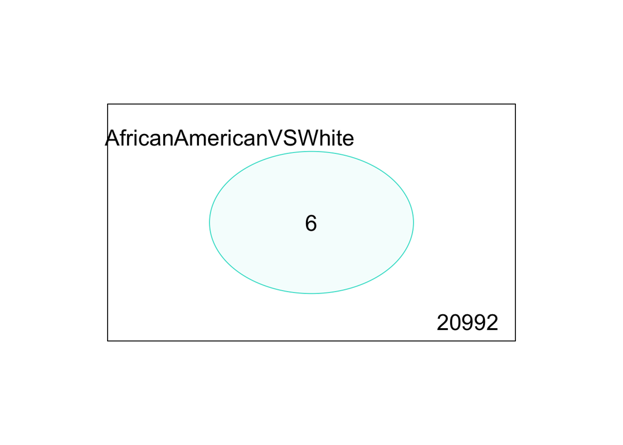

```r
vennDiagram(dt[,1], circle.col = c("turquoise", "salmon"))
```

```r
write.fit(tfit, dt, file="results.txt")
```

## Examining individual DE genes from top to bottom

Genes are most differentially expressed are listed using a function called “toptreat”.

```r
AfricanAmerican.vs.White <- topTreat(tfit, coef=1, n=Inf)
head(AfricanAmerican.vs.White)
```

```
##                            ENSEMBL    SYMBOL TXCHROM     logFC     AveExpr
## ENSG00000230076.1  ENSG00000230076      <NA>    <NA>  5.074280  0.09154117
## ENSG00000233913.7  ENSG00000233913      <NA>    <NA>  4.223815  2.13205482
## ENSG00000134184.11 ENSG00000134184     GSTM1    chr1  5.577464  0.96425031
## ENSG00000226278.1  ENSG00000226278      <NA>    <NA>  5.770465 -0.36666142
## ENSG00000229051.1  ENSG00000229051 LINC01788    <NA> -4.424352 -1.66729016
## ENSG00000165899.9  ENSG00000165899     OTOGL   chr12 -2.504723  0.05846375
##                            t      P.Value    adj.P.Val
## ENSG00000230076.1  10.053688 2.499969e-11 5.249435e-07
## ENSG00000233913.7   9.103813 2.360939e-10 2.478750e-06
## ENSG00000134184.11  6.137316 6.977828e-07 4.884015e-03
## ENSG00000226278.1   5.563459 3.608895e-06 1.523758e-02
## ENSG00000229051.1  -5.540870 3.628341e-06 1.523758e-02
## ENSG00000165899.9  -5.397879 4.695390e-06 1.643230e-02
```

## Using graphical representations of differential expression results

To summarize the genes, the log foldchange is plot against the log counts per million using the plotMD function.

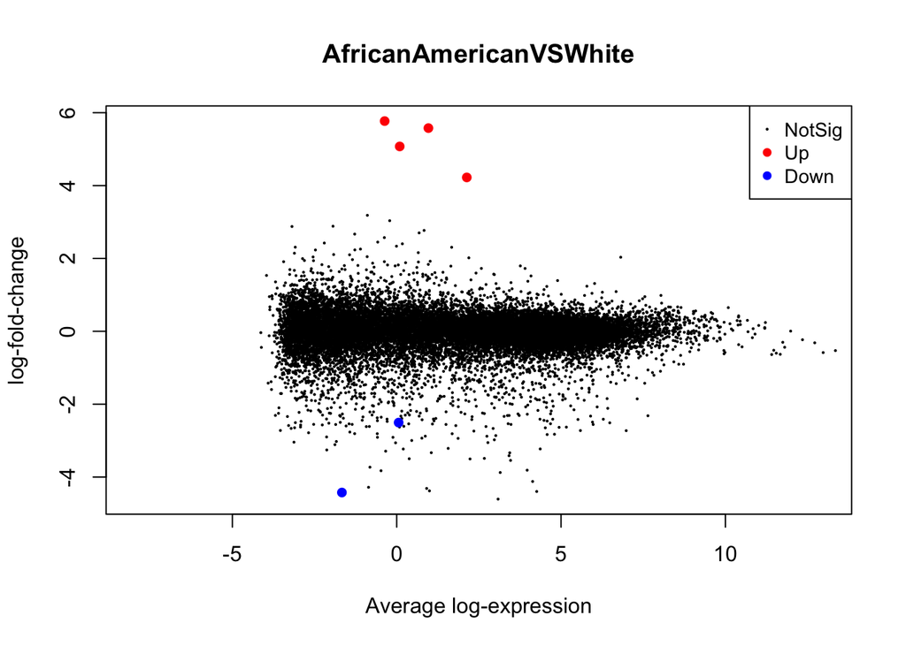

```r
plotMD(tfit, column=1, status=dt[,1], main=colnames(tfit)[1],
       xlim=c(-8,13))
```

This plot shows a small subset of up-regulated genes. This could be used as a test to to analyze the difference in regulations of the gene between races.

A more interactive version of this plot can be created using Glimma.

```r
glMDPlot(tfit, coef=1, status=dt, main=colnames(tfit)[1],
         side.main="ENSEMBL", counts = lcpm, groups=group, launch = TRUE)
```

We could generate a heatmap to see the highest expressed genes. Since my dataset is bigger than the normal dataset used in Vignette, so I chose to use heatmap.plus function. Heatmap.plus is a library can help us create the heatmap for larger datasets.

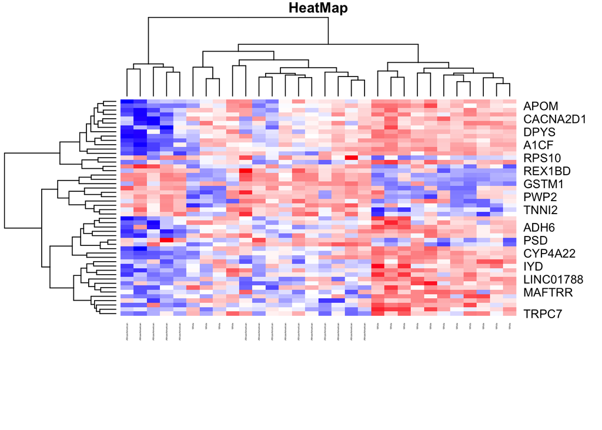

```r
library(gplots)
library(heatmap.plus)
AfricanAmerican.vs.White.topgenes <- AfricanAmerican.vs.White$ENSEMBL[1:50]
i <- which(v$genes$ENSEMBL %in% AfricanAmerican.vs.White.topgenes)
mycol <- colorpanel(1000,"blue","white","red")
par(cex.main=0.8,mar=c(1,1,1,1))
heatmap.plus(lcpm[i,], scale="row", labRow=v$genes$SYMBOL[i], labCol=group, col=mycol, cexRow=1,cexCol=0.2, margins = c(8,6), main="HeatMap")
```

To explain the heatmap, the red area stand for up-regulated genes, the blue area stand for down-regulated genes, and the white area stand for no significant gene expression change.

# Gene set testing with camera

## loading in the c2 curated gene set.

The c2 curated gene set can be used for analyzing human genes in R. The human_c2_v5p2.rdata file can be downloaded from the Broad Institute’s Molecular Signatures Database (MSigDB) collection.

```r
load("human_c2_v5p2.rdata")
```

And then I checked the first several gene sets within the Homo sapiens c2 curated gene sets. And I got the total number of gene sets within Hs. c2

```r
names(Hs.c2)[1:5]
```

```
## [1] "KEGG_GLYCOLYSIS_GLUCONEOGENESIS"
## [2] "KEGG_CITRATE_CYCLE_TCA_CYCLE"
## [3] "KEGG_PENTOSE_PHOSPHATE_PATHWAY"
## [4] "KEGG_PENTOSE_AND_GLUCURONATE_INTERCONVERSIONS"
## [5] "KEGG_FRUCTOSE_AND_MANNOSE_METABOLISM"
```

```r
length(Hs.c2)
```

```
## [1] 4729
```

Then I used the ids2indices function to map the gene IDs between the c2 gene sets and the v object. And I also create a contrast matrix that can compare the African American patients’ data versus the White patients’ data. The camera function shows a competitive test to check whether the genes in a given set are highly ranked in terms of differential expression relative to genes that are not in the set.

```r
idx <- ids2indices(Hs.c2, rownames(v$genes))
```

```r
cam.AfricanAmericanVSWhite <- camera(v, idx,design,contrast = contr.matrix[,1])
head(cam.AfricanAmericanVSWhite,5)
```

```
##                                     NGenes Direction       PValue       FDR
## CHEN_PDGF_TARGETS                       10      Down 0.0000416868 0.1970535
## REACTOME_RNA_POL_I_PROMOTER_OPENING     42        Up 0.0005139808 0.9996656
## REACTOME_MEIOTIC_SYNAPSIS               53        Up 0.0011834254 0.9996656
## SHARMA_ASTROCYTOMA_WITH_NF1_SYNDROM      2      Down 0.0015167466 0.9996656
## KEGG_RNA_DEGRADATION                    22      Down 0.0016199929 0.9996656
```

The barcode plot represents the relative enrichment of gene sets among the highly or lowly ranked genes between the African American v.s White female in kidney cancer cases.

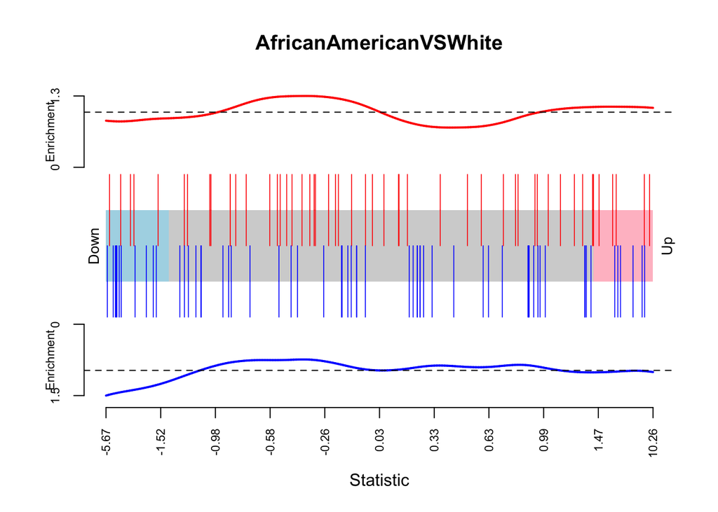

```r
barcodeplot(efit$t[,1], index=idx$LIM_MAMMARY_LUMINAL_MATURE_UP,
          index2=idx$LIM_MAMMARY_LUMINAL_MATURE_DN, main="AfricanAmericanVSWhite")
```